# Global Change Biology | Environmental Change Journal | Wiley Online Library

[Global Change Biology](https://onlinelibrary-wiley-com.reed.idm.oclc.org/journal/13652486)

[Volume 17, Issue 5](https://onlinelibrary-wiley-com.reed.idm.oclc.org/toc/13652486/2011/17/5) p. 1788-1797

[figure not shown]

Full Access

# Temperature effects on oxygen thresholds for hypoxia in marine benthic organisms

[RAQUEL VAQUER-SUNYER](https://onlinelibrary-wiley-com.reed.idm.oclc.org/authored-by/VAQUER%E2%80%90SUNYER/RAQUEL),

[CARLOS M. DUARTE](https://onlinelibrary-wiley-com.reed.idm.oclc.org/authored-by/DUARTE/CARLOS+M.),

First published: 30 September 2010

https://doi-org.reed.idm.oclc.org/10.1111/j.1365-2486.2010.02343.x

Citations: 201

Raquel Vaquer-Sunyer, tel. +34 971610897, fax +34 971611761, e-mail: raquel.vaquer@uib.es

## Abstract

The effect of warming on the oxygen requirements and the survival of benthic organisms under hypoxia was tested using a meta-analysis of published results of experiments evaluating the effects of temperature on the median lethal time and median lethal concentration of benthic macrofauna under hypoxia. The meta-analysis confirmed that survival times under hypoxia were reduced by on average 74% and that median lethal concentration increased by on average 16% when marine benthic organisms were exposed to warmer temperatures. Warming reduced survival times of marine benthic macrofauna under hypoxia by a median of 3.95±1.67 h °C<sup>−1</sup> and increased the oxygen thresholds for hypoxia-driven mortality by a median of 1.02±0.15% saturation °C<sup>−1</sup> or 0.07±0.01 mg O<sub>2</sub> L<sup>−1</sup> °C<sup>−1</sup>. The corresponding *Q*<sub>10</sub> values averaged 3.01±0.29 for the median survival time and 2.09±0.20 for the median lethal oxygen concentration. Use of these *Q*<sub>10</sub> values predicts that the 4 °C warming expected during the 21st century will lead to survival times 35.6% lower under hypoxia and that the threshold oxygen concentrations for high mortality to occur will increase by, on average, 25.5% if bottom water temperature increased by 4 °C. Hence, ocean warming is expected to increase the vulnerability of benthic macrofauna to reduced oxygen concentrations and expand the area of coastal ecosystems affected by hypoxia.

## Introduction

Global warming is forecasted to lead to an increase in the mean global temperature by 1.8–4 °C by the end of the 21st century (Meehl *et al*., 2007), with important consequences on climate, hydrology, biodiversity, and biogeochemical cycles. The impacts of global warming will compound with those derived from other human pressures, such as the impacts from excess nutrient inputs, a major driver of the proliferation of hypoxia in the coastal ocean (Cloern, 2001; Kemp *et al*., 2009). Dissolved oxygen is the property that has experienced the steepest global decline in the marine environment (Diaz & Rosenberg, 1995; Diaz, 2001). Oxygen deficiencies have increased in frequency, duration, and severity in the world's coastal areas over the last decades (Diaz & Rosenberg, 2008). As a consequence hypoxia is emerging as a major threat to marine coastal biota (Vaquer-Sunyer & Duarte, 2008). Environmental factors, such as the presence of sulphide (Vaquer-Sunyer & Duarte, 2010), and hypercapnia and low pH (Boleza *et al*., 2001; Rosa & Seibel, 2008), which are increasing with the increased *p*CO<sub>2</sub> and acidification of ocean waters (Caldeira & Wickett, 2003; Zeebe *et al*., 2008), increase the mortality of marine organisms exposed to hypoxia. Warming may also contribute to exacerbate hypoxia and its consequences for marine life.

Temperature is believed to be a key factor controlling the extent of hypoxia (Conley *et al*., 2007), acting through a multitude of interacting processes, including the role of ocean warming in increasing stratification and reducing ventilation of marine waters (Sarmiento *et al*., 1998). The likelihood of strengthened stratification alone, from increased surface water temperature, is sufficient to worsen hypoxia where it already occurs and will trigger its occurrence in other coastal areas (Rabalais *et al*., 2009). Stramma *et al*. (2008) documented the vertical expansion of the intermediate-depth low oxygen zones in the eastern tropical Atlantic and the equatorial Pacific during the past 50 years. The hypoxic boundary has shoaled up to 90 m in the Californian Current System (Bograd *et al*., 2008). The oxygen content of the Oxygen Minimum Zones (OMZ) has been documented to decline in the tropical Pacific, Atlantic and Indian Oceans (Stramma *et al*., 2009; Stramma *et al*., 2010). Both the expansion and shoaling of OMZ have been attributed to ocean warming (Keeling & Garcia, 2002; Whitney *et al*., 2007).

The effects of climate change on seawater temperature are modulated by multiple factors such as changes in wind patterns, with the associated changes in surface currents, circulation and mixing processes. The formation of a new hypoxic area off the inner-shelf of the Oregon coast documented in 2002 (Service, 2004) was attributed to deviations in the circulation of the California Current System (Grantham *et al*., 2004) that reflect the occurrence of large-scale wind-stress anomalies over the northeast Pacific in 2002 (Murphree *et al*., 2003). Increasing temperature may intensify coastal upwelling (Bakun, 1990; Bakun & Weeks, 2004), which may lead to lower sea-surface temperature and a subsequent decline in oxygen in the associated bottom waters when low grazing pressure allows the sinking and subsequent respiratory decomposition of primary production (Bakun & Weeks, 2004). Ocean warming is not limited to surface waters, as there is overwhelming evidence for a global trend toward significant warming of the upper ocean (from 0 to 700 m depth) over the past 16 years (Lyman *et al*., 2010). Warming has also been reported in deeper waters of the West Mediterranean Sea, where temperature increased between 0.12 and 0.5 °C from 1948 to 2005 in the upper layers (0–200 m), between 0.05 and 0.2 °C from 1948 to 2000 in the mid layer (from 200 to 600 m depth) and between 0.03 and 0.1 °C from 1948 to 2005 in deep waters (from 1000 to 2000 m, Vargas-Yáñez *et al*., 2008; Bladé*et al*., 2010), consistent with reports of significant warming of ocean bottom-waters elsewhere (Fukasawa *et al*., 2004; Masuda *et al*., 2010). Seawater warming is also prevalent in coastal waters, where most hypoxic events have been documented, as reflected in reports of warming in shallow bays along the Swedish West coast (Cossellu & Nordberg, 2010), intense warming at rates ranging from 0.03 to 0.04 °C year<sup>−1</sup> between 1974 and 2001 in the continental shelf of the Catalonian Sea (West Mediterranean, Vargas-Yanez *et al*., 2005) and maximum seawater temperatures elevated over 3 °C around Majorca island (West Mediterranean) over the past decade relative to the previous four decades (Marbà & Duarte, 2010).

Increasing temperature diminishes oxygen solubility (Carpenter, 1966; Garcia & Gordon, 1992), and increases the respiration rates of organisms (Jones, 1977; Enquist *et al*., 2003), as temperature plays a fundamental role in regulating metabolic processes (Iriberri *et al*., 1985; White *et al*., 1991). Increased temperature will likely affect the responses of marine benthic organisms to hypoxia because metabolic rates increase exponentially with temperature (Brown *et al*., 2004). Whereas both photosynthesis and respiration are enhanced with warming, within the limits imposed by resources (light, CO<sub>2</sub> and nutrients, and organic substrates and oxygen concentration, respectively), the Metabolic Theory of Ecology (Brown *et al*., 2004) predicts that respiration rates should increase faster with warming than photosynthetic rates do, as activation energies for autotrophic processes are half of those for heterotrophic processes (Harris *et al*., 2006). On the basis of this differential response, Harris *et al*. (2006) predicted that warming of an hypothetical north-eastern Atlantic estuary by 4 °C in the summer would result in a 20% increase in net primary production and a 43% increase in heterotrophic metabolism, resulting in a 16% decrease of the P : R ratios and an increasing likelihood of system heterotrophy. These predictions, however, may be conservative, as they refer to specific metabolic rates and do not consider possible effects of warming on autotrophic and heterotrophic biomass. Müren *et al*. (2005) showed that the ratio of heterotrophic to autotrophic biomass increased fivefold and the production to respiration ratio decreased sixfold when temperature increased from 5 to 10 °C in experimental mesocosms. A decrease in ecosystem P : R ratios with increasing temperature could result in a net decrease in oxygen concentration, increasing the frequency and severity of hypoxic events. However, increased temperature may also affect the vulnerability of organisms to low oxygen concentration, as the increased organismal respiration rates also increases their oxygen demand, affecting the oxygen thresholds for hypoxia. However, the effect of water temperature and warming on the oxygen thresholds for hypoxia has been evaluated for individual species alone. Here we evaluate, on the basis of a meta-analysis of available experimental results for individual species, the effects of temperature on the oxygen thresholds for marine benthic macrofauna.

## Methods

We searched the Web of Science and Scholar Google for reports of hypoxia using the keywords ‘hypoxia’, ‘marine’, ‘benthic’ and ‘sea’, and their combinations to guide the search. This search delivered more than 6000 published reports of responses of benthic marine organisms to hypoxia, which were then examined further for the availability of experimental assessments of responses to reduced oxygen concentration that included temperature and/or evaluated them at different experimental temperatures. We also searched the list of papers cited in those papers retrieved by the search. This more restricted search delivered a total of 363 experimental assessments examining the median lethal time (LT<sub>50</sub>), representing the statistically derived time interval at which 50% of a given population dies after exposure to low O<sub>2</sub> levels, involving 108 different species of marine benthos; and a total of 213 experimental assessments examining the median lethal concentration (LC<sub>50</sub>), representing the statistically derived O<sub>2</sub> concentration at which 50% of the organisms in a given population die, involving 39 different species of marine benthos. Data on the experimental water temperature were derived from the papers, and where these were only reported in graphic, the data were extracted using the digitizing software graph click 2.9.2.

Quantile regression was used to assess changes in the probability distribution of thresholds of hypoxia for marine benthic organisms with increasing temperature. The relationship between the thresholds of hypoxia, as described by LC<sub>50</sub> [% saturation (% sat.) and mg O<sub>2</sub> L<sup>−1</sup>] and LT<sub>50</sub> (h), and water temperature was described by fitting the relationship between the 95%, 50% (median) and 5% quantiles for the distribution of these thresholds and water temperature. Quantile regression estimates multiple rates of change (slopes), from the minimum to maximum response, providing a more complete description of the relationships between variables missed by other regression methods focused on prediction of the mean value (Cade & Noon, 2003). Quantile regression can be considered as an extension of classical least squares estimation of conditional mean models to the estimation of a compilation of models for several conditional quantile functions, considering the median as the central parameter (Koenker, 2005). Statistical analyses were performed using jmp 7.02 for simple regression analyses, anova and ancova, and r for quantile regression.

## Results

We found a total of 363 published experiments involving 108 species pertaining to 10 different taxonomic groups of benthic macrofauna reporting the water temperature at which the median lethal time (LT<sub>50</sub>, h) was assessed (Fig. 1a) and 213 experimental assessments involving 39 species from three different taxonomic groups (mollusca, fishes and crustaceans) of benthic marine fauna reporting the incubation temperature at which the median lethal concentration (LC<sub>50</sub>, % sat. and mg O<sub>2</sub> L<sup>−1</sup>) was assessed (Fig 1b and c). The aim of this broad comparison is to test for evidence of a temperature-dependence in the thresholds of hypoxia for coastal benthic organisms. The experiments compiled include a diversity of procedures and species, which may add variability to the analysis, contributing to the residual variability.

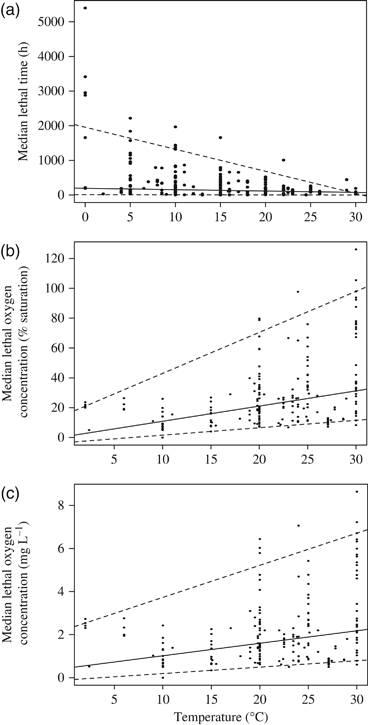

**Figure 1**

(a) The relationship between the median lethal time (LT<sub>50</sub>, h) and water temperature for the different experiments. The solid line represents the fitted regression for the median or the 50% quartile [LT<sub>50</sub> (h)=194.70 (±34.04) – 3.95 (±1.67) × temperature; *N*=363, *P*<0.03]. The dashed lines represent the fitted regression for the 95% quantile [LT<sub>50</sub> (h)=1956.25 (±430.54)−63.62 (±19.10) × temperature; *n*=363, *P*<0.001] and the 5% quantile [LT<sub>50</sub> (h)=12.95 (±6.63)−0.45 (±0.31) × temperature; *n*=363, *P*=0.15]. (b) The relationship between the median lethal concentration (LC<sub>50</sub>, %sat.) and the water temperature for the different experiments. The solid line represents the fitted regression for the median or the 50% quartile [LC<sub>50</sub> (%sat.)=0.71 (±2.91)+1.02 (±0.15) × temperature; *n*=213, *P*<0.0001]. The dashed lines represent the fitted regression for the 95% quantile (LC<sub>50</sub> (% sat.)=15.50 (±8.99)+2.75 (±0.47) × temperature; *n*=213, *P*<0.0001) and the 5% quantile (LC<sub>50</sub> (% sat.)=−3.37 (±3.62)+0.50 (±0.15) × temperature; *n*=213, *P*<0.002). (c) The relationship between the median lethal concentration (LC<sub>50</sub>, mg O<sub>2</sub> L<sup>−1</sup>) and the water temperature for the different experiments. The solid line represents the fitted regression for the median or the 50% quartile [LC<sub>50</sub> (mg O<sub>2</sub> L<sup>−1</sup>)=0.44 (±0.27)+0.06 (±0.01) × temperature; *n*=212, *P*<0.0001]. The dashed lines represent the fitted regression for the upper 95% quartile [LC<sub>50</sub> (mg O<sub>2</sub> L<sup>−1</sup>)=2.24 (±0.68)+0.15 (±0.04) × temperature; *n*=212, *P*<0.0001] and the lower 5% quartile [LC<sub>50</sub> (mg O<sub>2</sub> L<sup>−1</sup>)=−0.10 (±0.32) +0.03 (±0.01) × temperature; *n*=212, *P*<0.02] (see Supporting Information for data sources).

Examination of the relationship between LT<sub>50</sub> and experimental temperature showed that the range of LT<sub>50</sub> values observed became narrower with increasing temperature, with most experiments conducted showing relatively low LT<sub>50</sub> values at high temperature (Fig. 1a). This was confirmed using quantile regression fitted to the 95% and the 5% quantiles as well as the 50% quartile (median) of the change in LT<sub>50</sub> with increasing temperature (Fig 1a). The 95% quantile regression, estimating the temperature dependence of the maximum LT<sub>50</sub> expected for a given water temperature, indicated a decrease in the maximum LT<sub>50</sub> by 63.62±19.10 h per each °C of temperature increase, whereas the 5% quantile regression, estimating the temperature dependence of the minimum LT<sub>50</sub>, showed only a decrease by 0.45±0.31 h (27 min) for each °C increase. The median LT<sub>50</sub> declined by 3.95±1.67 h for each °C of temperature increase (Fig 1a). The variability in LT<sub>50</sub>, as described by the 5–95% interquantile range, declined with increasing temperature from values of 12.95 to 1956.25 h at the lower end of seawater temperature (0 °C) to 0–47.5 h at the high end (30 °C, Fig. 1a).

The intercepts and slopes of the regressions between LT<sub>50</sub> and experimental temperature showed significant differences among taxonomic groups. No significant relationship between LT<sub>50</sub> and temperature was found for fish, crustaceans, annelids, cnidarians, bryozoans, echinoderms and platyhelminthes, but priapulidans showed the steepest decline in median lethal time (205.2±2.08 h °C<sup>−1</sup>, *R*<sup>2</sup>=0.99, *P*<0.007, *N*=3), whereas molluscs showed a much smaller decrease in survival time (41.90±5.46 h °C<sup>−1</sup>, *R*<sup>2</sup>=0.25, *P*<0.0001, *N*=189) with warming.

The relationship between LC<sub>50</sub> (% sat.) and experimental temperature showed increasing variability in LC<sub>50</sub> and increasing median lethal oxygen concentrations with increasing temperature. Quantile regression describing the relationship between the 95% quantile of LC<sub>50</sub> and water temperature showed an increase in LC<sub>50</sub> (% sat.) by 2.75 (±0.47)% sat. [or 0.15 (±0.04) mg O<sub>2</sub> L<sup>−1</sup> when the analysis focussed on concentrations] per °C increase, whereas the 5% quantile regression increased by only 0.50 (±0.15)% sat. [i.e. 0.03 (±0.01) mg O<sub>2</sub> L<sup>−1</sup>] for each °C of temperature increase. The median LC<sub>50</sub> (% sat.) increased by 1.02 (±0.15)% sat. [i.e. 0.06 (±0.01) mg O<sub>2</sub> L<sup>−1</sup>] for each °C of temperature increase (Fig 1b and c). The variability in LC<sub>50</sub> (% sat.), as described by the 5–95% interquantile range, increased with increasing temperature from 0.00 to 15.50% sat. (i.e. 0.00–2.24 mg O<sub>2</sub> L<sup>−1</sup> when the analysis focussed on concentrations) at the lower end of marine temperature (0 °C) to 11.63–98.00% oxygen saturation (0.80–6.74 mg O<sub>2</sub> L<sup>−1</sup>) at the high end (30 °C, Fig. 1b and c).

There were significant differences in the intercept and the slope of the relationships describing the temperature-dependence of LC<sub>50</sub> (% sat.) for different taxonomic groups, as no significant relationship between LC<sub>50</sub> (% sat.) and temperature was found for fish, which may be a consequence of the range of physiological capacities in the fish species included in the data set. Crustaceans showed the highest increase in median lethal O<sub>2</sub> concentration with warming (2.40±0.36% oxygen saturation °C<sup>−1</sup>, *R*<sup>2</sup>=0.26, *P*<0.0001, *N*=125; or 0.15±0.03 mg O<sub>2</sub> L<sup>−1</sup>, *R*<sup>2</sup>=0.21, *P*<0.0001, *N*=124) and molluscs showed the lowest increase in LC<sub>50</sub> with warming (1.42±0.36% oxygen saturation °C<sup>−1</sup>, *R*<sup>2</sup>=0.40, *P*<0.0007, *N*=26; or 0.09±0.02 mg O<sub>2</sub> L<sup>−1</sup>, *R*<sup>2</sup>=0.37, *P*<0.001, *N*=26).

We found a total of 189 published experiments involving 21 species from five different taxonomic groups of benthic macrofauna where the median lethal time (LT<sub>50</sub>, h) of the subject organism was assessed at different temperatures and a total of 165 published experiments involving 10 species belonging to three different taxonomic groups (fishes, crustaceans and molluscs) of benthic macrofauna where the median lethal oxygen concentration (LC<sub>50</sub>) of the subject organism was assessed at different temperatures.

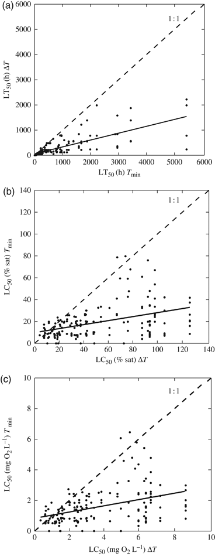

**Figure 2**

(a) The relationship between the median lethal time at increased temperature (LT<sub>50</sub>Δ*T*) and median lethal time at lower temperature (LT<sub>50</sub>) (units: h). LT<sub>50</sub>Δ*T* (h)=80.04 (±22.68)+0.26 (±0.02) × LT<sub>50</sub> (h). (R<sup>2</sup>=0.54, *P*<0.0001) *n*=189. The solid line represents regression line and dashed line represents the line 1 : 1. (b) The relationship between the median lethal concentration at one temperature (LC<sub>50</sub>*T*<sub>min</sub>) and median lethal concentration at increased temperature (LC<sub>50</sub>Δ*T*) (units: % oxygen saturation). LC<sub>50</sub>*T*<sub>min</sub> (% oxygen saturation)=9.85 (±2.01)+0.18 (±0.03) × LC<sub>50</sub>Δ*T* (% sat.). (*R*<sup>2</sup>=0.17, *P*<0.0001) *n*=165. The solid line represents regression line and dashed line represents the line 1 : 1. (c) The relationship between the median lethal concentration at one temperature (LC<sub>50</sub>*T*<sub>min</sub>) and median lethal concentration at increased temperature (LC<sub>50</sub>Δ*T*) (units: mg O<sub>2</sub> L<sup>−1</sup>). LC<sub>50</sub>*T*<sub>min</sub> (mg O<sub>2</sub> L<sup>−1</sup>)=0.84 (±0.16)+0.20 (±0.04) × LC<sub>50</sub>Δ*T* (mg O<sub>2</sub> L<sup>−1</sup>). (*R*<sup>2</sup>=0.16, *P*<0.0001) *n*=165. The solid line represents regression line and dashed line represents the line 1 : 1 (see Supporting Information for data sources).

Calculated *Q*<sub>10</sub> values for the change in LT<sub>50</sub> (h) with increasing temperature showed a broad range of values with an average (±SE) *Q*<sub>10</sub> describing the temperature-dependence of LT<sub>50</sub> of 3.01±0.29 (Fig. 3a). Analysis of covariance (ancova) did not yield evidence of significant differences among taxonomic groups or life stages in slope or intercept (*t*-test, *P*>0.05) in *Q*<sub>10</sub> values for the change in LT<sub>50</sub> with increasing temperature. Calculated *Q*<sub>10</sub> values for the change in LT<sub>50</sub> (h) with increasing temperature showed statistically significant differences among organisms with different motility capacities, with sessile organisms having higher *Q*<sub>10</sub> values than those for motile ones (*F*=5.35, *P*<0.02).

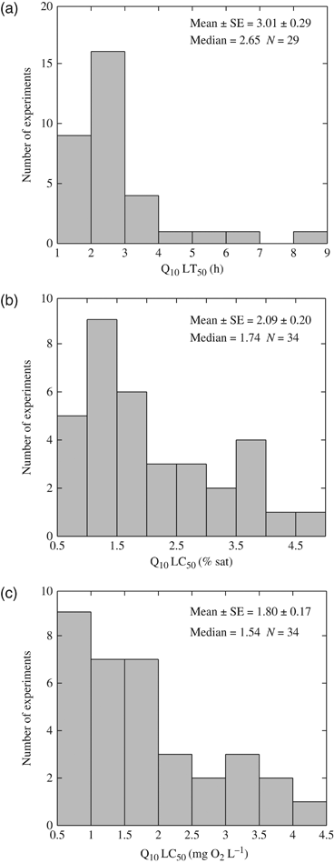

**Figure 3**

Frequency distribution for *Q*<sub>10</sub> values for median lethal time (a) and for median lethal oxygen concentration in % sat. (b) and in mg O<sub>2</sub> L<sup>−1</sup> (c). Data on *Q*<sub>10</sub> for median lethal time calculated from (Gamble, 1970; Dries & Theede, 1974; Shumway *et al*. 1983; Oeschger & Theede, 1986; Stickle *et al*. 1989; Brooks *et al*. 1991; Johnson & McMahon, 1998; de Zwaan *et al*. 2001) and on *Q*<sub>10</sub> for median lethal oxygen concentration calculated from (E. L. Shimps & J.A. Rice personal comment; Vargo & Sastry, 1977; Stickle *et al*. 1989; Schurmann & Steffensen, 1992; Hoback & Barnhart, 1996; Plante *et al*. 1998; Miller *et al*. 2002; Cerezo & Garcia, 2004; Ishibashi *et al*. 2005; Shimps *et al*. 2005; Goodman & Campbell, 2007).

## Discussion

The results presented support the hypothesis that the thresholds of hypoxia for benthic marine macrofauna are significantly affected by temperature and provide estimates of the extent of change in these thresholds with increasing temperature. However, our results derive from a limited set of species, so the generality of the conclusions reached need be tested further when data for additional species becomes available. Moreover, these results derive from experiments where temperature changes were imposed over short time scales, whereas microevolutionary changes may increase the resistance of organisms to hypoxia as the oceans warm over the 21st century. Our predictions may provide worst-case scenarios.

Meta-analysis results indicate that the survival time of benthic organisms under hypoxia is reduced and the oxygen concentration at which high mortality (LC<sub>50</sub>, % sat.) takes place increases with increasing temperature indicating that the oxygen requirements of benthic macrofauna increase with increasing temperature. Moreover, the range of survival time and median lethal oxygen concentration for benthic macrofauna were also significantly affected by increasing temperature.

The LT<sub>50</sub> (h) and LC<sub>50</sub> (% sat.) for individual species varies considerably for any water temperature. But there was a tendency for survival times under hypoxia to decrease and the oxygen requirements for survival to increase with increasing temperature. The mean *Q*<sub>10</sub> values describing the temperature-dependence of the thresholds of hypoxia for benthic macrofauna are comparable to those describing the temperature dependence of respiration rates (*Q*<sub>10</sub> values around 2–3, cf. Neori & Holm-Hansen, 1982; Raven & Geider, 1988), providing evidence that the temperature-dependence of thresholds of hypoxia for benthic macrofauna is associated with increased metabolic oxygen demands at increasing temperature.

*Q* <sub>10</sub> values showed higher values for sessile species than for motile species for both median lethal time and median lethal oxygen concentration. The implication of a high *Q*<sub>10</sub> value for LC<sub>50</sub> (% sat.) or LT<sub>50</sub> (h) is that the oxygen requirements of sessile organisms, which cannot escape the hypoxic areas, will increase faster with warming than those for mobile organisms, suggesting that warming will render sessile organisms particularly vulnerable to hypoxia. The mean *Q*<sub>10</sub> values for LT<sub>50</sub> (h) for sessile species was 5.06, implying a reduction in their survival time by 25.3% and 47.7% with 1.8 °C and 4 °C warming, respectively. For an oyster (*Crassostrea virginica*) living in waters with 30 salinity at 20 °C, this reduction means a decrease in survival time from 20 days to 14 days with a 1.8 °C warming and down to 10 days with a 4 °C warming. A reduction in survival time by half can lead to a significant population reduction in areas such as Chesapeake Bay, where severe seasonal hypoxia occurs and temperature is one of the key controls on hypoxia development (Kemp *et al*., 2009). The average *Q*<sub>10</sub> values for LC<sub>50</sub> (%sat.) for sessile species was 3.72, resulting in an increase of median lethal oxygen content by 21.1% and 40.9% with warming of 1.8 °C and 4 °C, respectively. The consequences of such steep *Q*<sub>10</sub> values for sessile species are that the oxygen requirements for survival (as LC<sub>50</sub>) of a hypothetical oyster population living at 20 °C and 30 salinity would increase from 19% sat. (i.e. 1.46 mg O<sub>2</sub> L<sup>−1</sup>) to 27% or 23% sat. (i.e. 1.95 or 1.71 mg O<sub>2</sub> l<sup>−1</sup>) with a warming of 4 °C and 1.8 °C, respectively.

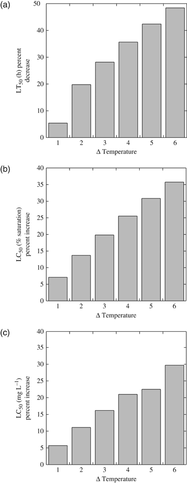

**Figure 4**

Changes in hypoxia thresholds calculated from *Q*<sub>10</sub> values derived here. (a) Percentage of decrease of median lethal time expected with different water warming; (b) increase of the median lethal oxygen content expected for different water temperature increases in % sat.; (c) in mg O<sub>2</sub> L<sup>−1</sup>.

Oxygen concentrations are also expected to be reduced in a warmer ocean rendering the effects of ocean warming on hypoxia-driven mortality steeper than expected from the effect of temperature on the oxygen requirements of organisms. Conley *et al*. (2009) calculated that the hypoxic area in Danish coastal waters will double with a 4 °C increase as a consequence of changes in oxygen solubility alone, maintaining other factors constant. At the global scale, ocean models predict global declines in average dissolved oxygen concentration, due to ocean warming, over the next century ranging between 1% and 7% (Keeling *et al*., 2010). Shaffer *et al*. (2009) predicted long-term ocean oxygen depletion and a great expansion of ocean oxygen-minimum zones for scenarios involving high emissions or high climate sensitivity to greenhouse gas emissions. Whereas Keeling *et al*. (2010) provided evidence for a global oxygen decline in ocean waters, rates of oxygen decline tend to be greater in coastal waters compared with open ocean ones (Gilbert *et al*., 2010), consistent with observations around the world (Gilbert *et al*., 2005; Bograd *et al*., 2008; Diaz & Rosenberg, 2008). Yet, reduced oxygen concentration with increasing temperature and increased oxygen requirements by benthic macrofauna are only two of a variety of processes affecting hypoxia in a warmer ocean, as a warmer ocean is also likely to show increased stratification, reduced ventilation, and an increased oxygen drawdown by respiratory processes, which are enhanced with increasing temperature (Brown *et al*., 2004; Harris *et al*., 2006).

Hence, ocean warming is likely to produce an increase in the extent and severity of marine macrofauna mortality under hypoxia by the combined effect of reducing dissolved oxygen concentration in the ocean and increasing the oxygen requirements (Najjar *et al*., 2010) and the sensitivity to reduced oxygen concentrations of marine biota. These combined effects will further reduce the quality and spatial extent of suitable habitat for a wide range of aerobic organisms. For example, Niklitschek & Secor (2005) demonstrated, in a simulation on the combined effects of warming and hypoxia in the Chesapeake Bay system, that a small warming of 1 °C during summer months could practically eliminate suitable habitats for juvenile Atlantic sturgeon (*Acipenser oxyrhynchus*). Suitable habitat for most metazoans is restricted by water temperature, among other factors, as all organisms live within a limited range of water temperatures, allowing optimized structural and kinetic coordination of cellular, molecular, and systemic processes (Portner & Farrell, 2008).

The meta-analysis conducted here suggests that warming will negatively impact the survival of benthic organisms under low oxygen conditions by reducing survival times under hypoxia by a median of 3.95±1.67 h °C<sup>−1</sup> and by increasing the oxygen thresholds for hypoxia-driven mortality by a median of 1.02±0.15% sat. °C<sup>−1</sup> or 0.07±0.01 mg O<sub>2</sub> L<sup>−1</sup> °C<sup>−1</sup> across the species for which experimental evidence is available. Hypoxia is already expanding globally across coastal waters (Diaz & Rosenberg, 2008; Rabalais *et al*., 2009; Rabalais *et al*., 2010), parallel to increased flux of nutrients to the coastal zone and warming of coastal waters (Rabalais *et al*., 2009; Rabalais *et al*., 2010). The synergy between two global changes, oxygen depletion and warming of coastal waters, threatens coastal benthic macrofauna. Aggravation of the negative effects of spreading hypoxia by the effect of warming in rising the O<sub>2</sub> requirements of organisms and, therefore, the O<sub>2</sub> thresholds for hypoxia together with the fact that warming will accelerate oxygen depletion suggest that the threats to marine biota derived from hypoxia will be amplified in a context of global warming and may, thus, be greater than hitherto anticipated.

## Acknowledgments

This research is a contribution to the ‘Water bodies in Europe: Integrative Systems to assess Ecological status and Recovery (WISER)’ project, funded by FP7 (contract number #226273) and project MEDEICG, funded by the Spanish Ministry of Science and Innovation (number CTM2009-07013). We thank A. Steckbauer for help with translations of German papers. C. M. D. was supported by a sabbatical fellowship from the Spanish Ministry of Education.

## Citing Literature

[Volume17, Issue5](https://onlinelibrary-wiley-com.reed.idm.oclc.org/toc/13652486/2011/17/5)

May 2011

Pages 1788-1797

[figure not shown]